# Git Foundations

### Fetching & pulling from remote repository

- to get data from your remote projects run:

  `git fetch <remote_repository>`

**What does fetch do?**

- goes to that remote project and pulls all the data from it that you don’t have yet.
- you should then have references to all the branches from that remote, which you can merge in or inspect at any time.

**and what happens when you clone repository?**

- `git clone` automatically adds that remote repository under the name `origin`.
  - `git fetch` origin fetches any new work that has been pushed to that server since you cloned (or last fetched from) it.
  - `git fetch` only downloads the data to your local repository
  - `git fetch` doesn’t automatically merge it with any of your work or modify what you’re currently working on. You have to merge manually when ready.

**What if you want to fetch and automatically merge?**

- suppose your current branch is set up to track a remote branch
- use the `git pull` to automatically `fetch` and then `merge` that remote branch into your current branch.
  - its an easier workflow for you
  - by default `git clone` automatically sets up your local master branch to track the remote master branch on the server you cloned from.
  - `git pull` generally fetches data from the server you originally cloned from and automatically tries to merge it into the code you’re currently working on.

#### Pushing to a remote repository

- pushing is done in order to share your current work
- you have to `push it upstream`.
- use the command `git push <remote> <branch>`

**Example:**

- suppose you want to push your `master` branch to your `origin` server
  - remember cloning sets up those names automatically

`git push origin master`

**Note**

- push works only if you cloned from a server to which you have write access and if nobody has pushed in the meantime.
- If you and someone else clone at the same time and they push upstream and then you push upstream, your push will be rejected.
- You’ll have to fetch their work first and incorporate it into yours before you’ll be allowed to push.

**more of this when we consider `branching`**

**Example of `git push`**

- on local repository, edit `dbpandas.py` by adding the line print("New statement")
- stage the file and commit in one go `git commit -a -m 'print statement'`
- you can check `git status`
- now push `git push origin master`

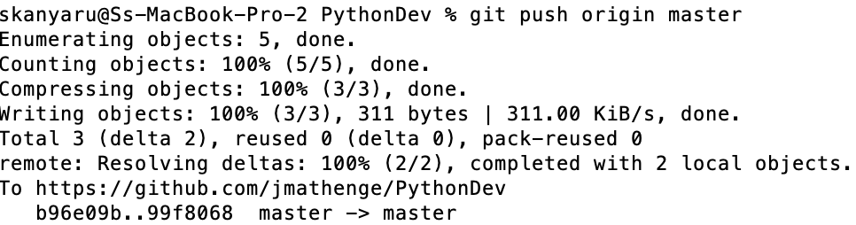

  Let me now check my remote repository on github

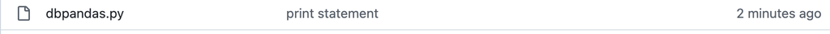

**Inspect your remote repository from local**

- use `git remote show origin`

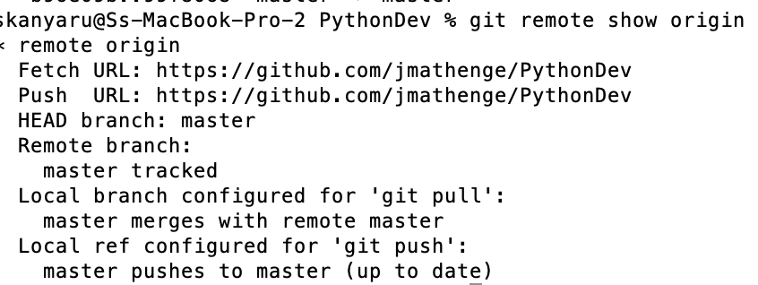

**what the output tells us**

- gives a list of the URLs for the remote repository as well as the tracking branch information.
- tells us that if you’re on the master branch and you run `git pull`, it will automatically merge the remote’s master branch into the local one after it has been fetched.

### Renaming remote repository

- `git remote rename` - used to change a remote repository's shortname. e.g., to rename `p_dev` to `python_dev`:

  ```
  `git remote rename p_dev python_dev`
  ```

The above rename changes all your remote-tracking branch names too. That is from p_dev/master to python_dev/master.

### Removing a remote repository

- to remove a remote repo, do

  `git remote remove python_dev` Now check with `git status`:
- all remote-tracking branches and configuration settings associated with that remote are also deleted.

## Task

**In this task, you will review and practice several git commands**

1. Somewhere in your file system, create a folder called `Git_GitHub_Tutorial`.
2. Navigate to this folder
3. Initialize your project with `git init`.
   - tell Git to get ready to start watching your files for every change that occurs.
4. Create a file called `todolist.txt` and place in it this content

   MY TO-DO LIST
   1. Write an article.
   2. Code.
   3. Study books.
   4. Attend classes on time.
   5. Visit aunt.
   6. Apply for remote jobs. **a small detour about GitHub**
- GitHub is an online hosting service for Git repositories.
- it enables remote management of git projects
- GitHub lets you store your repo on their platform

**How to push a repository to GitHub**

a. Create a GitHub account

- visit https://github.com/ and create an account

b. Create a repository

- click on the `+` symbol on the top right corner of the page then choose `New repository`. Give your repo a name then scroll down and click on `Create repository`.

c. Add and commit file(s)

Before you `add` and `commit` your files, you need to understand the stages of a file being tracked by Git.

**Committed state**

- A file is in the committed state when all the changes made to the file have been saved in the local repo. Files in the committed stage are files ready to be pushed to the remote repo (on GitHub).

**Modified state**

- A file in the modified state has some changes made to it but it's not yet saved. This means that the state of the file has been altered from its previous state in the committed state.

**Staged state**

- A file in the staged state means it is ready to be committed. In this state, all necessary changes have been made so the next step is to move the file to the commit state.
1. Add files to git i.e., stage the files
   - stage your files using `git add .`
2. Now commit your files
- use the git commit command and provide an appropriate message e.g. `git commit -m "added the todolist file"`
1. Next, push your local repo to GitHub **some insights**
- when you created the repo on GitHub, you should have been redirected to a page that shows you how to create a repo locally or push an existing one.
- here, the project already exists locally so we will use commands in the `..or push an existing repository from the command line` section.

These are the commands:

git remote add origin https://github.com/jmathenge/git_github_tutorial.git git branch -M main git push -u origin main

#### Notes

- use your own url for your repo
- the first command is associating your remote repo to a name called origin
- the second command is renaming the `master` branch to `main`
- the third command is pushing main repo `up` to the remote
1. Make changes to the `todolist.txt` file as follows

   ```
    MY TO-DO LIST

    1. Write an article.
    2. Code.
    3. Study books.
    4. Attend classes on time.
    5. Visit aunt.
    6. Apply for remote jobs.
    7. Practice code
   ```

   - run the command `git status`
2. What happens to the file after changes in step 8 above?
- suppose you want to `push` it to GitHub, what do you have to do?
  - stage it
  - commit to local repo with an appropriate message
  - then push

### Questions and answers

1. What does `git add` do?
   - adds files from working directory to staging area
2. What does `git commit` do?
   - produces a checksum, SHA-1, or the identifier for each file that becomes part of your local repo.
   - produces a snapshot of your history of changes
   - using the SHA-1, we can revert back to previous states of our files

### How to revert back to a previous state/commit

- first, we check our commit history using `git log`
  - commits in my repo look like this

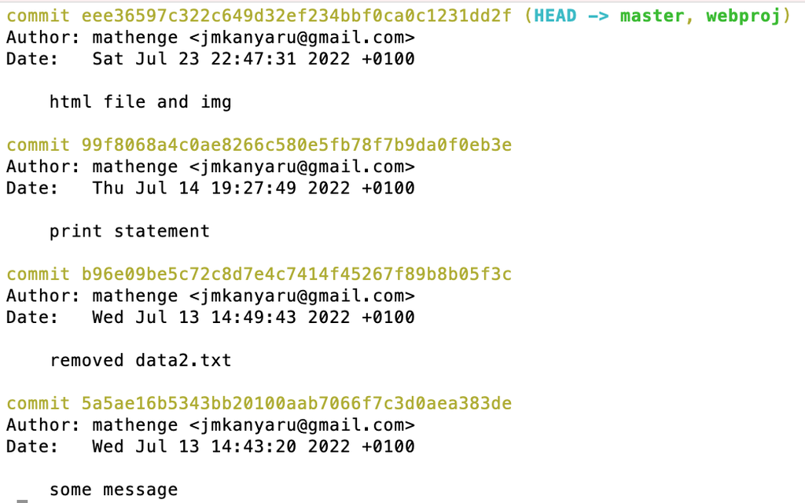

- There is a commit on Wed Jul 13 at 14:49 that involved removal of data2.txt file

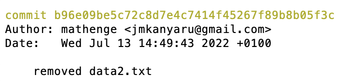

- Now, I want to revert to the commit before it so I can see the data2.txt file, assuming that I am interested in it again.
  - do `git checkout 5a5ae16b5343bb20100aab7066f7c3d0aea383de`
  - then do a directory listing, and you will see file data2.txt
- You can make changes to data2.txt, stage and commit if you wish
- Revert to the current `HEAD` using `git switch -`